# Regression Discontinuity

24 February, 2021

## Outline

- Overview of Regression Discontinuity (RD)
- Real world example from own work

## RD

- Originates in education
- Thistlethwaite DL, Campbell DT. Regression-discontinuity analysis: an alternative to the ex post facto experiment. [J Educ Psychol. 1960;51:309–317.](https://pdfs.semanticscholar.org/0ebb/29615b1569e9ee219f536c9ad64ae5fce36d.pdf)
- Impact of student recognition on future performance where test score was used to allocate different forms of recognition.
- 2 Elements. 1) Running or forcing variable 2) Threshold or cut-point.

## Education (and health) examples

[Systematic review](https://journals.lww.com/epidem/Fulltext/2021/01000/Regression_Discontinuity_Designs_in_Health__A.12.aspx)

- [Age](https://www.nber.org/system/files/working_papers/w21610/w21610.pdf) - school starting age, effect of starting school older
- [Year](https://academic.oup.com/restud/article-abstract/72/1/189/1582636) - compulsory schooling laws, effect of education
- [Class size](https://www.tandfonline.com/doi/full/10.1080/09645292.2013.789826?needAccess=true) - effect of class size, threshold of 25.
- [Number of schools](https://onlinelibrary.wiley.com/doi/abs/10.1002/hec.1643) - effect of school HIV teaching, towns with 1 to 4 secondary schools
- [Test score](https://bmcmedicine.biomedcentral.com/track/pdf/10.1186/s12916-020-01536-7.pdf) - effect of grammar school, 11 plus exam

## Randomised intervention as RD

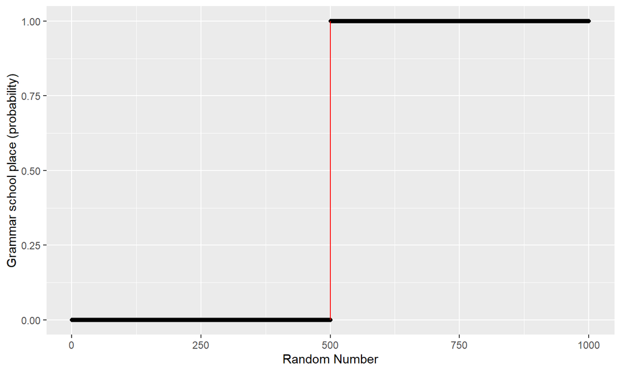

## Randomised intervention as RD

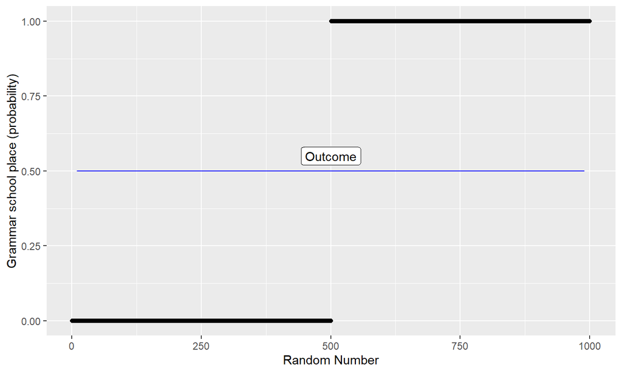

## Randomised intervention as RD

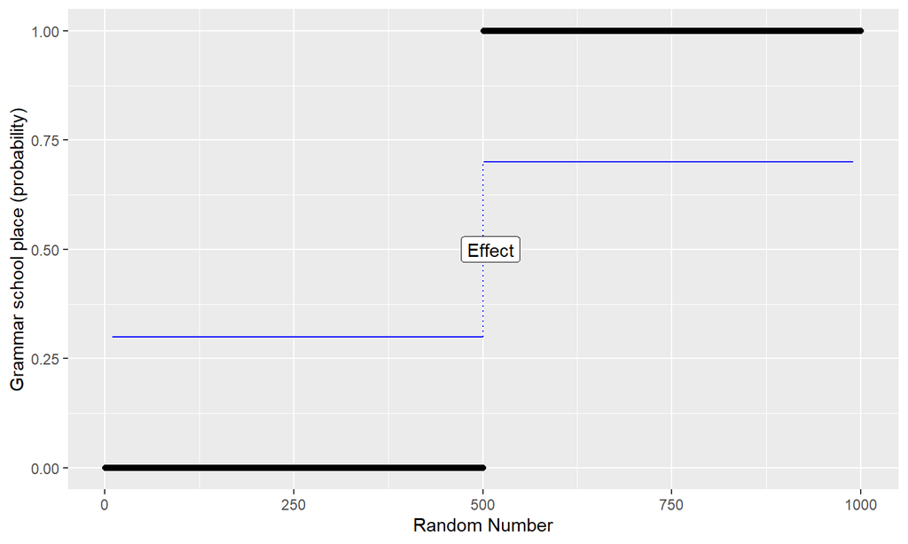

## Non randomized intervention as RD

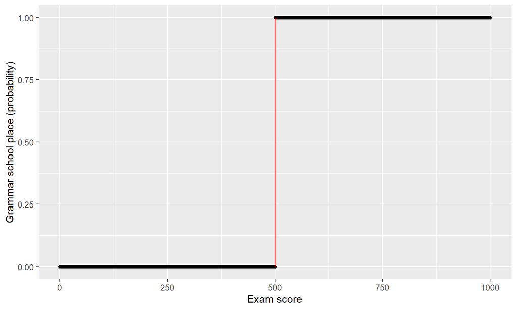

## Non randomized intervention as RD

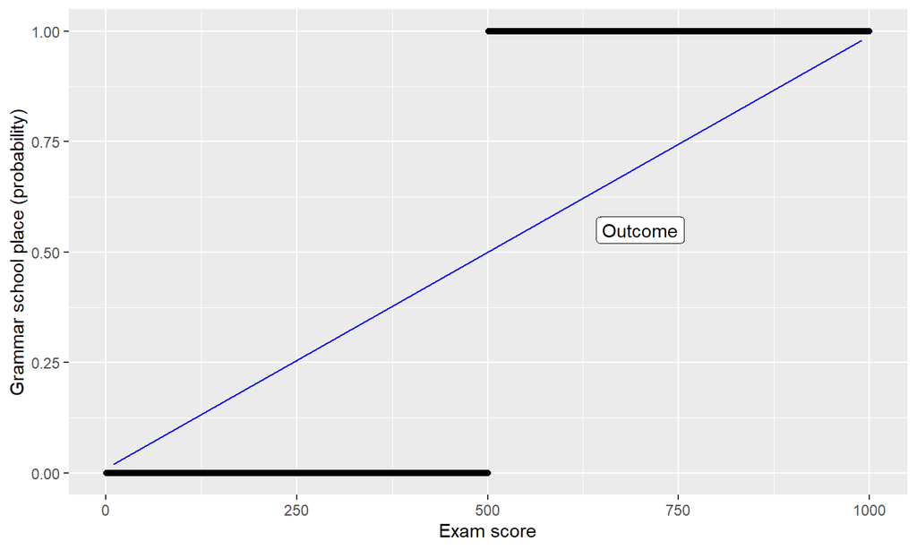

## Non randomized intervention as RD

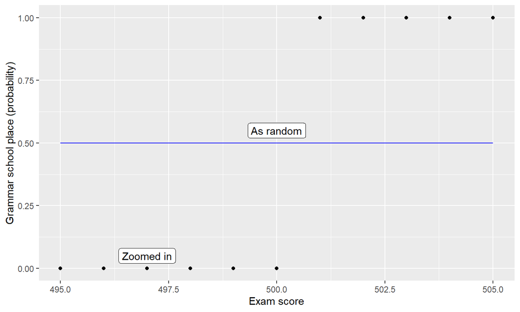

## Non randomized intervention as RD

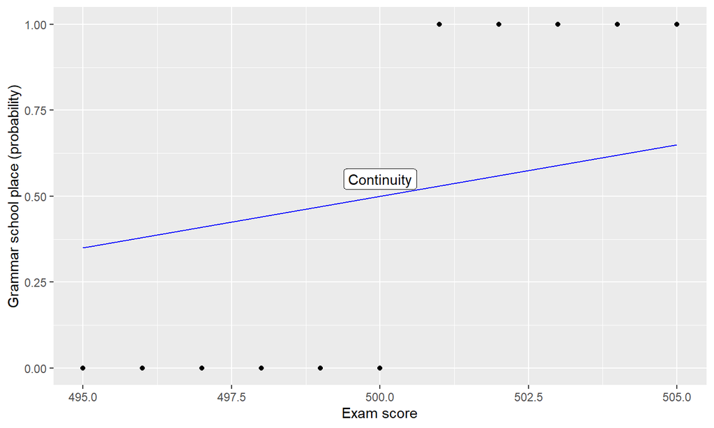

## Summary

- RD treatment effect is local to cut-point
- As random based on “measurement error”
- Continuity based on smooth null relationship of outcome across cut point
- Bandwidth is running score band either side of cut-point, wider gives more cases but may increase bias.
- [Further reading](https://rdpackages.github.io/references/Cattaneo-Idrobo-Titiunik_2019_CUP.pdf) and [here](https://rdpackages.github.io/references/Cattaneo-Idrobo-Titiunik_2020_CUP.pdf)

## [Example](https://bmcmedicine.biomedcentral.com/track/pdf/10.1186/s12916-020-01536-7.pdf)

- [Grammar schooled socio-economically advantaged in adulthood.](https://www.iser.essex.ac.uk/publications/working-papers/iser/2014-05)
- Translate into health benefits?
- 1960s Aberdeen pupils took 11 plus type test
- [Aberdeen cohort followed and linked to health data](https://www.abdn.ac.uk/birth-cohorts/1950s/)
- [Registered report](https://www.cos.io/initiatives/registered-reports)

## Example

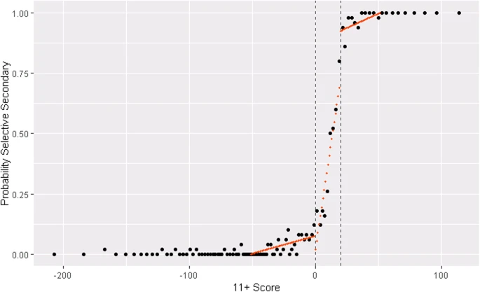

## Example

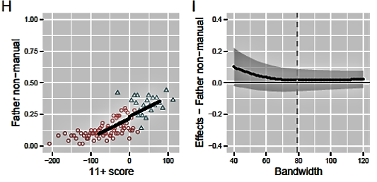

## Example

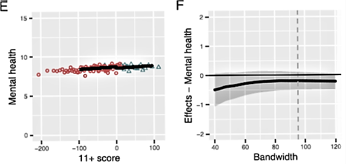

## Thanks for listening

Talk and code - https://github.com/frankpopham/rdtalk